# Tidy Tuesday Volcano

Brandon Brenes

2024-11-08

## Description

We will be making a *geom_map* plot using *geom_polygo*n and *geom_point* displaying the **volcanoes in Indonesia**, the volcanoes **tectonic setting** and **elevation**.

## Libraries

```r
# libraries #

library(here)
library(maps)
library(readr)
library(dplyr)
library(bslib)
library(mapdata)
library(mapproj)
library(tidyverse)
```

## Data

### Load data

The volcano data came from a *tiny_tuesday* repository named **Volcano Eruptions.** The world map data came from the **maps package**

```r
# load data #

volcano <- readr::read_csv('https://raw.githubusercontent.com/rfordatascience/tidytuesday/master/data/2020/2020-05-12/volcano.csv')

world<-map_data("world")

# display #
head(world)
```

```
##        long      lat group order region subregion
## 1 -69.89912 12.45200     1     1  Aruba      <NA>
## 2 -69.89571 12.42300     1     2  Aruba      <NA>
## 3 -69.94219 12.43853     1     3  Aruba      <NA>
## 4 -70.00415 12.50049     1     4  Aruba      <NA>
## 5 -70.06612 12.54697     1     5  Aruba      <NA>
## 6 -70.05088 12.59707     1     6  Aruba      <NA>
```

```r
# display #
head(volcano)
```

```
## # A tibble: 6 × 26
##   volcano_number volcano_name    primary_volcano_type last_eruption_year country
##            <dbl> <chr>           <chr>                <chr>              <chr>
## 1         283001 Abu             Shield(s)            -6850              Japan
## 2         355096 Acamarachi      Stratovolcano        Unknown            Chile
## 3         342080 Acatenango      Stratovolcano(es)    1972               Guatem…
## 4         213004 Acigol-Nevsehir Caldera              -2080              Turkey
## 5         321040 Adams           Stratovolcano        950                United…
## 6         283170 Adatarayama     Stratovolcano(es)    1996               Japan
## # ℹ 21 more variables: region <chr>, subregion <chr>, latitude <dbl>,
## #   longitude <dbl>, elevation <dbl>, tectonic_settings <chr>,
## #   evidence_category <chr>, major_rock_1 <chr>, major_rock_2 <chr>,
## #   major_rock_3 <chr>, major_rock_4 <chr>, major_rock_5 <chr>,
## #   minor_rock_1 <chr>, minor_rock_2 <chr>, minor_rock_3 <chr>,
## #   minor_rock_4 <chr>, minor_rock_5 <chr>, population_within_5_km <dbl>,
## #   population_within_10_km <dbl>, population_within_30_km <dbl>, …
```

### Data manipulation

First we will filter for Indonesia lat and long data and filter volcano data to only have a necessary variables and only Indonesia data.

```r
# world data manipulation #

indonesia <- world %>% filter(region == "Indonesia")
#filter for only Indonesia data


# volcano data manipulation #

indonesia_volcano_subset <- volcano %>%
  select(volcano_number, country, tectonic_settings, latitude, longitude, elevation) %>%
  filter(country == "Indonesia")
#filter for only Indonesia data and necessary columns


# display #

head(indonesia_volcano_subset)
```

```
## # A tibble: 6 × 6
##   volcano_number country   tectonic_settings        latitude longitude elevation
##            <dbl> <chr>     <chr>                       <dbl>     <dbl>     <dbl>
## 1         264020 Indonesia Subduction zone / Conti…    -8.34      116.      2997
## 2         268072 Indonesia Subduction zone / Ocean…    -0.53      127.      1030
## 3         266020 Indonesia Subduction zone / Conti…     0.75      124.      1795
## 4         263290 Indonesia Subduction zone / Conti…    -7.73      113.      3339
## 5         265090 Indonesia Subduction zone / Ocean…    -4.52      130.       596
## 6         264010 Indonesia Subduction zone / Conti…    -8.24      115.      1717
```

## Plot

Using the *indonesia* with the **geom_polygon()** function and *indonesia_volcano_subset* data with the **geom_point** function overlay-ed, I created a map of volcanoes in Indonesia. I then used the **scale_size_continuous** and **labs()** function to express the relationship between the size of the point and the elevation of the volcano The color was filled using the tectonic setting as shown in the legend.

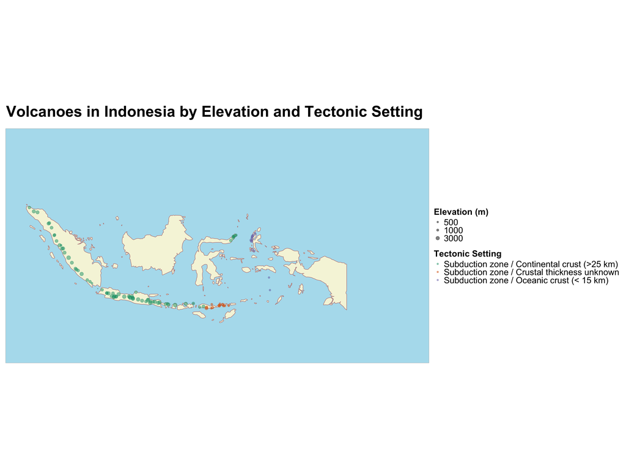

```r
indonesia_volcano_plot <- ggplot() +
    #plot the shape of Indonesia
    geom_polygon(data = indonesia,
                 aes(x = long, y = lat, group = group),
                 fill = "beige", color = "#BC8F8F") + #beige and brown
 #add points for each volcano, with size based on elevation and color by tectonic_settings
    geom_point(data = indonesia_volcano_subset,
               aes(x = longitude, y = latitude, size = elevation, color = tectonic_settings),
               alpha = 0.5) + #add transparency for better visibility
    #customize the size scale for elevation
    scale_size_continuous(
        name = "Elevation (m)",
        breaks = c(500, 1000, 3000),
        range = c(0.5, 4)  # increase the range for bigger points
    ) +
    #use a mercator projection
    coord_map(projection = "mercator", xlim = c(95, 150), ylim = c(-15, 15)) +
    theme_light()+
    scale_color_brewer(name = "Tectonic Setting", palette = "Dark2")+
    labs(title = "Volcanoes in Indonesia by Elevation and Tectonic Setting")+
    #customize background color and layout
  theme(
        plot.title = element_text(face = "bold", hjust = 0.1, size = 35, margin = margin(b = 20)),
        #bold title, left aligned
        plot.margin = margin(t = 10, r = 10, b = 10, l = 10),
        #add margin for spacing
        panel.background = element_rect(fill = "lightblue2"),
        #set background of plot area
        legend.background = element_blank(),
        #remove background from the legend area
        legend.key = element_blank(),
        #make the legend keys (symbols) transparent
        axis.text = element_blank(),  #remove axis labels and grid
        axis.ticks = element_blank(),
        axis.title = element_blank(),
        panel.grid = element_blank(),
        legend.title = element_text(size = 20, face = "bold"), #legend title
        legend.text = element_text(size = 20),#legend text
        legend.spacing = unit(0.2, "cm"),  #reduce space between the legends
        legend.box.spacing = unit(0.2, "cm")  #reduce space between legends
    )

indonesia_volcano_plot
```

## What did I learn?

I learned how to make a ggmap displaying **two variables** using the color and the point size to represent different values. The colors display an interesting pattern showing the longitudinal change in tectonic setting. I am also using a color blind friendly pallet, which is something that I’ve been meaning to make a habit in my research analyses. I also used a new rmarkdown theme!